# Logistic Regression Analysis Framework

#Background The **Chocolate** dataset contains information about various chocolates, including their cocoa percentage, type, and rating. The goal of this analysis is to use logistic regression to determine if the cocoa percentage can predict whether a chocolate is *dark* or *milk*.

- **Dataset**: Chocolate
- **Objective**: Predict whether a chocolate is *dark* (binary variable: `isDark`) based on its cocoa percentage (`Cocao`).
- **Response Variable**: `isDark` (1 = *dark* chocolate, 0 = *milk* chocolate)
- **Predictor Variable**: `Cocao` (percentage of cocoa)

#### **Hypotheses**

- **Null Hypothesis (H₀)**: Cocoa percentage does not significantly affect the likelihood of chocolate being *dark* ($\beta_1 = 0$).
- **Alternative Hypothesis (Hₐ)**: Cocoa percentage significantly affects the likelihood of chocolate being *dark* ($\beta_1 \neq 0$).

#### **Logistic Regression Model**

The logistic regression model is as follows:

$$P(isDark = 1 | Cocao) = \frac{e^{\beta_0 + \beta_1 \cdot Cocao}}{1 +
e^{\beta_0 + \beta_1 \cdot Cocao}}$$

Where: - $\beta_0$ = **Intercept** - $\beta_1$ = **Coefficient for `Cocao`**

### **Analysis**

````r
``` r
# Fit logistic regression model
chocolate_glm <- glm(isDark ~ Cocao, data = chocolate, family = "binomial")
# Summary of the model
summary(chocolate_glm)
````

```
##
## Call:
## glm(formula = isDark ~ Cocao, family = "binomial", data = chocolate)
##
## Coefficients:
##              Estimate Std. Error z value Pr(>|z|)
## (Intercept)  -2802.67  158605.55  -0.018    0.986
## Cocao           40.36    2282.22   0.018    0.986
##
## (Dispersion parameter for binomial family taken to be 1)
##
##     Null deviance: 1.7067e+03  on 1793  degrees of freedom
## Residual deviance: 5.6511e-07  on 1792  degrees of freedom
## AIC: 4
##
## Number of Fisher Scoring iterations: 25
```

###Graph

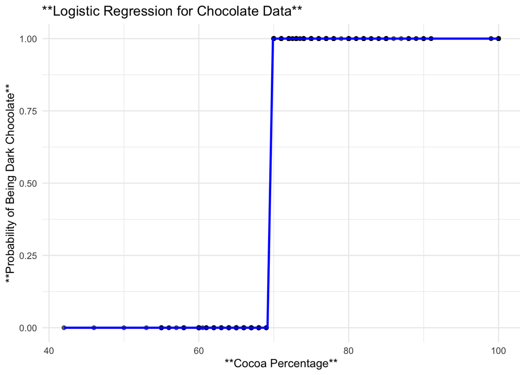

```r
# Scatterplot with logistic regression curve
ggplot(data = chocolate, aes(x = Cocao, y = isDark)) +
  geom_point(alpha = 0.6) +
  stat_smooth(method = "glm", method.args = list(family = "binomial"), se = FALSE, color = "blue") +
  labs(title = "**Logistic Regression for Chocolate Data**",
       x = "**Cocoa Percentage**",
       y = "**Probability of Being Dark Chocolate**") +
  theme_minimal()
```

### **Prediction**

#### Predict the Probability

````r
``` r
# Predict probabilities for specific cocoa percentages
new_data <- data.frame(Cocao = c(50, 70, 85))
predicted_probs <- predict(chocolate_glm, newdata = new_data, type = "response")
predicted_probs
````

```
##            1            2            3
## 2.220446e-16 1.000000e+00 1.000000e+00
```

## **Explanation**:

- The probabilities for each cocoa percentage indicate how likely a chocolate with that percentage is to be classified as *dark* chocolate.

#Exp (b1) The exponentiated coefficient $e^{\beta_1}$ represents the **odds ratio** for a 1% increase in cocoa percentage:

```r
# Calculate exp(b1)
exp_b1 <- exp(coef(chocolate_glm)["Cocao"])
exp_b1
```

```
##        Cocao
## 3.362251e+17
```